# Storage Capacity Estimate

The goal of this notebook is to estimate both contemporary storage capacity using the modified TDI approach developed by [Jones et al., [2018]](https://doi.org/10.1002/hyp.11405).

A few quick notes on data:

1. All data is housed in the Palmer Lab subdirectory. (Choptank/Nate/Storage_Capacity)
2. The 1m DEM was downloaded from [imap.maryland.gov](http://imap.maryland.gov/Pages/lidar-dem-download-files.aspx)
3. This script will be housed at [floodhydrology.com](http://floodhydrology.com/InundationHydRology/Dark_Bay_Demo.html)

# Step 1: Workspace Organization

As always, the first step is to define relevant directories, aquire required librairies, and download input data. Note, this anlaysis requires a DEM, wetland location, and wetland polygon, all of which can be found in the “Storage_Capacity” subdirectory on the Palmer Lab server. Further, the script also requires the user to specify the location of the “storage capacity” data directory, a scratch workspsace, and location of the [Whitebox Tools](http://www.uoguelph.ca/~hydrogeo/WhiteboxTools/index.html) executable. For SESYNC users, note that Whitebox cannot be initiated from the RStudio Server, and you will need to use the WynAnalytics virtual machine.

```r
#Clear memory (KH says not to do this...maybe I'll convert eventually)
rm(list=ls(all=TRUE))
```

```r
#Defin relevant working directories
data_dir<-"//storage.research.sesync.org/palmer-group-data/choptank/Nate/Storage_Capacity/"
scratch_dir<-"C:\\ScratchWorkspace\\"
wbt_dir<-"C:/WBT/whitebox_tools"
#Download packages
library(raster)
library(sp)
library(rgdal)
library(rgeos)
library(dplyr)
#Download package from GIT
library(devtools)
install_github("FloodHydrology/InundationHydRology")
library(InundationHydRology)
#Download relevant data
dem<-raster(paste0(data_dir,"II_work/jl_dem"))
pnt<-readOGR(paste0(data_dir,"II_Work/."),"Wetland_Locations", verbose = F)
pnt<-pnt[pnt$Name=="DK",]
burn<-readOGR(paste0(data_dir,"II_Work/."),"DarkBay_Burn")
```

# Step 2: Wetland Delineation!

Below, we delineate indiviudal basins for each wetland.

```r
#Burn wetland into DEM
dem_burn<-GIW_burn(dem, burn)
#Identify depressions in DEM
giws<-GIW_identification(
        dem=dem_burn,                       #DEM in question
        min_size=100,                       #Minimum depression size (in map units)
        workspace="C:\\ScratchWorkspace\\", #Scratch Workspace
        wbt_path="C:/WBT/whitebox_tools")   #WBG toolbox location
#Identify wetland subshed
subshed<-GIW_subshed_delineation(
        dem=dem_burn,      #DEM
        depressions=giws,  #depression from GIW_identification tool
        wetland=pnt)       #spatialpoint of wetland location
#Devleop stage storage relationship
storage<-GIW_stage_storage(
        subshed = subshed, #Subshed delineated in previous step
        dem = dem_burn,    #DEM
        z_max = 1,         #Maximum inundation depth
        dz = 1/12)          #Inundation Interval
#Print max inundation extent
inundation<-GIW_max_inundation(
  subshed,  #wateshed raster
  dem_burn, #DEM for the analysis
  storage   #Storage Curve
  )
```

# Step 3: Initial Results!!!

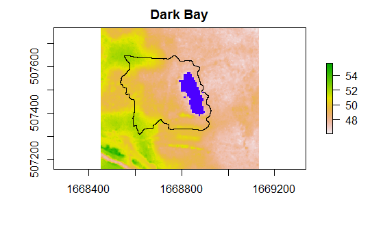

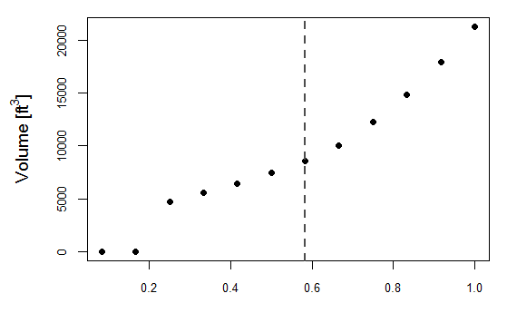